# House Prices in Ames, Iowa

Rafael Rodrigues Santana

November 20, 2018

# About the data

This dataset is from a Kaggle competition and it contains data about the houses sold between 2006 and 2010. This dataset is not the complete population of sales of houses because he is splitted into training and test data. At the same time, I don’t have information if the training and test data together are the complete population.

### Informations about the structure of the data:

- The dataset contains 1460 rows and 60 columns..
- A data wrangling process has already been carried out, dealing with missing values and relabeling the columns. The complete process can be accessed in the `data_wrangling` notebook.
- There aren’t duplicated rows in the dataset.

# Introduction

In this project, the main objective is to identify which variables influence in the increase or the decrease of the prices of the houses, exploring the relationship between the response variable and other variables in multiple ways.

There are some features that I believe that most people take into account before buying a house or setting the price of a house like:

- Size of the house.
- Neighborhood.
- Type of Neighborhood.
- Number of rooms.
- Number of bathrooms.
- Overall Quality of the house.
- Distance from the centerof the city.
- Size of the living room.
- Month of the year.
- Size of the garage.
- Age of the house.

# Univariate Plots Section

## Sale Price - Distribution

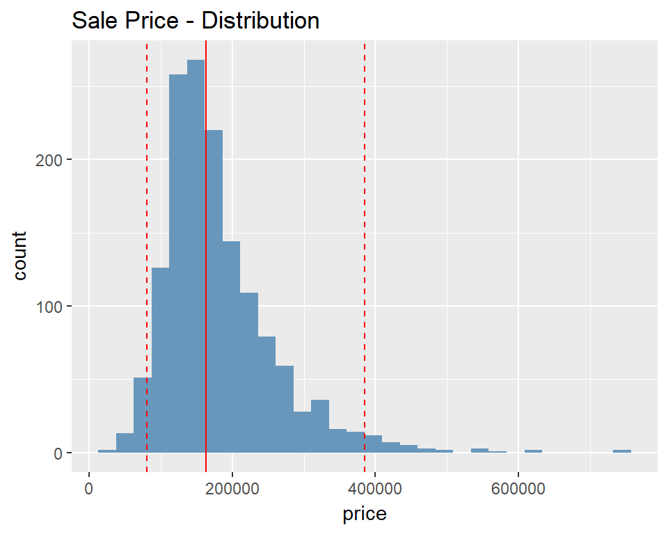

```
##    Min. 1st Qu.  Median    Mean 3rd Qu.    Max.
##   34900  129975  163000  180921  214000  755000
```

#### Observations:

- The distribution of the Sale Prices is skewed to the right.
- 95% of the houses were sold for, aproximately, between 80.000 and 400.000,00 dollars.
- The median price is 163.000,00 dollars.
- The IQR is, aproximately, 84.000,00 dollars.

## Lot Area - Distribution

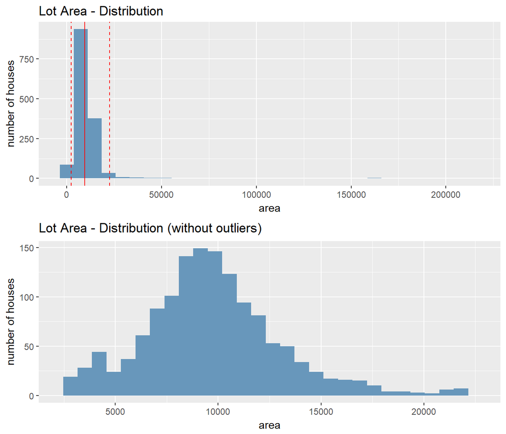

```
##    Min. 1st Qu.  Median    Mean 3rd Qu.    Max.
##    1300    7554    9478   10517   11602  215245
```

#### Observations:

- There are a lot of outliers in this variable, so I have created this two histograms comparing the distribution with outliers with the distribution without the upper and lower 2.5 bounds. The readability of the plot became better, so every time that I have to use the variable `LotArea`, I’ll remove the outliers.
- The median size of the lot size of the house is 9478 square feets.
- the IQR is, approximately, 4100 square feets.

### Age of the house

In our sample, there isn’t an age variable, however, there is a variable that shows the year that the house was constructed. So, I’ll create the variable by subtracting 2010 (the last year that we have data in our dataset) - `YearBlt` variable.

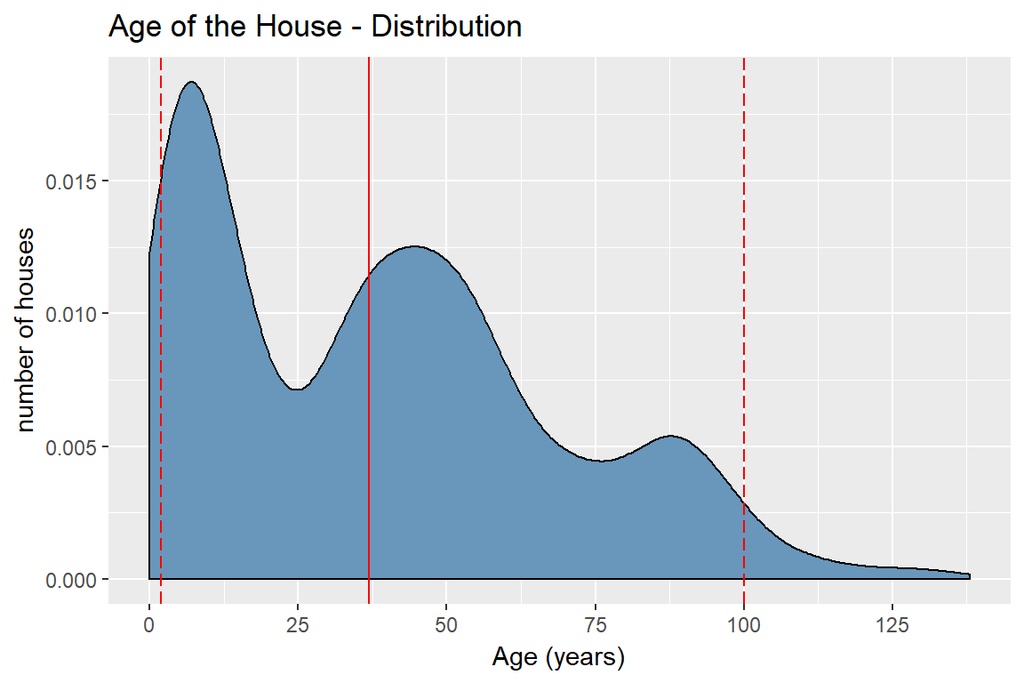

```
##    Min. 1st Qu.  Median    Mean 3rd Qu.    Max.
##    0.00   10.00   37.00   38.73   56.00  138.00
```

#### Observations:

The data is skewed to the right. Hence, the mean is greater than the median. Besides that, it’s important to note that there are houses in Ames that are really old, some of them having more than 100 years.

## Total number of houses sold by month

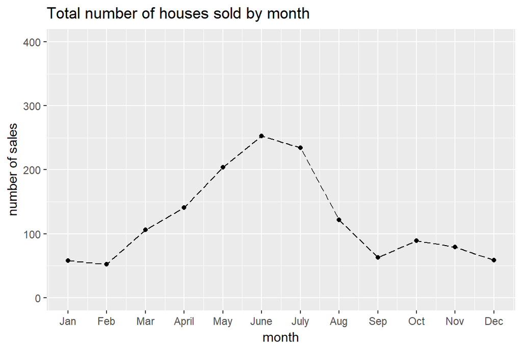

```
##
##   1   2   3   4   5   6   7   8   9  10  11  12
##  58  52 106 141 204 253 234 122  63  89  79  59
```

It seems that, in average, the number sales in the city of Ames are more common between April and August.

But, there are somethings that I want to check later like:

- The distribution of the months is simmetric? or is there data missing for some of the months?
- The amount of money spent is also high in those months?

## Number of high quality rooms by House

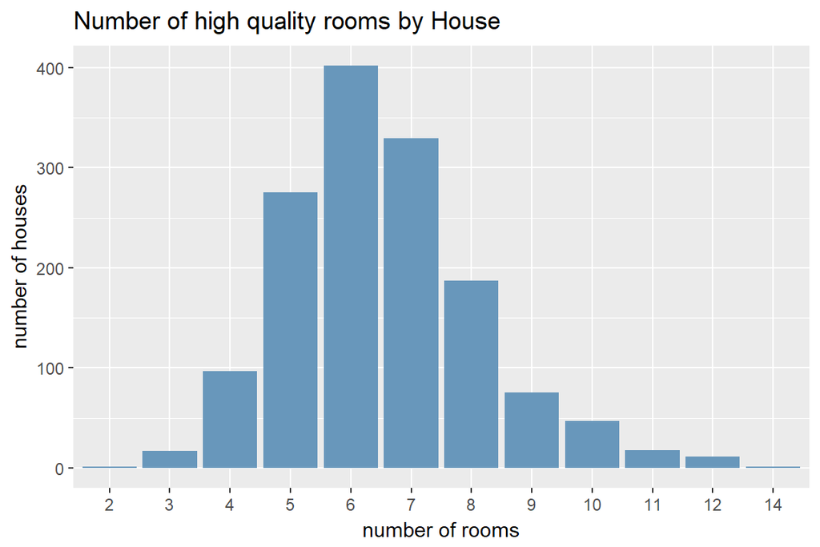

```
##
##   2   3   4   5   6   7   8   9  10  11  12  14
##   1  17  97 275 402 329 187  75  47  18  11   1
```

#### Observations:

- Most of the houses have between five and eight high quality rooms.
- The minimum number of rooms in a house in this dataset is 2.
- The maximum number of rooms in this dataset is 14.

## Garage’s capacity (cars) - Distribution

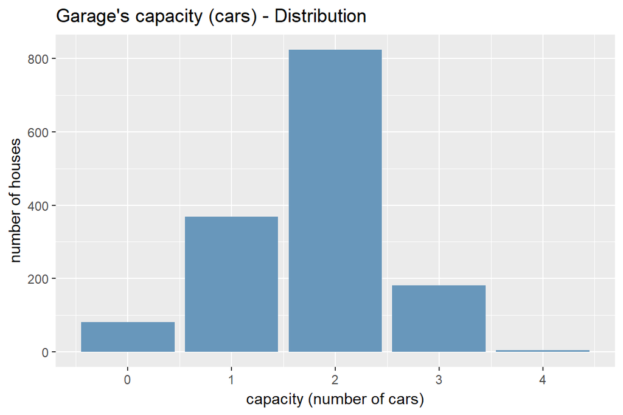

```
##
##   0   1   2   3   4
##  81 369 824 181   5
```

## Sales by Neighborhood

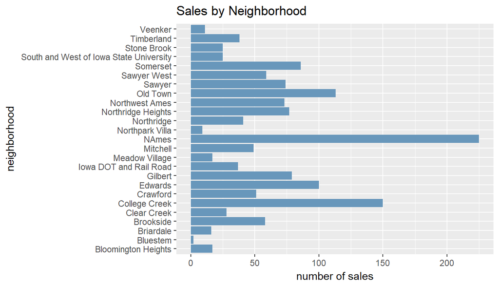

#### Observations:

- The neighborhoods with the higher demand for houses are North Ames, followed by College Crick, Old Town, Edwards and Somerset.
- Some of the neighborhoods almost doesn’t have sales, for example, Bluestem, North Park Villa and Veenker.

#### Questions to be answered in the next section:

- Locations where there were more demand for houses are, in average, more expensive?
- Is there a predominant zoning type in the neighborhoods?

# Univariate Analysis

In this section, we could get an overview of the sales across time and space. Besides that, we have also investigate the distribution in our dataset of the house prices, area, garage capacity and of the number of rooms.

In the next section, the focus of the analysis will be to understand the relationship between the prices and the other variables, taking as a first step, the doubts that have already emerged during the univariate analysis like:

- The data available is simmetric for all the months?
- Amount of Sales (US$) over time?
- Median Price of the houses by neighborhood?
- Zoning Type by Neighborhood?
- Sale Price versus Age of the house?
- Sales by Neighborhood?

# Bivariate Plots Section

### Sales by Month and Year

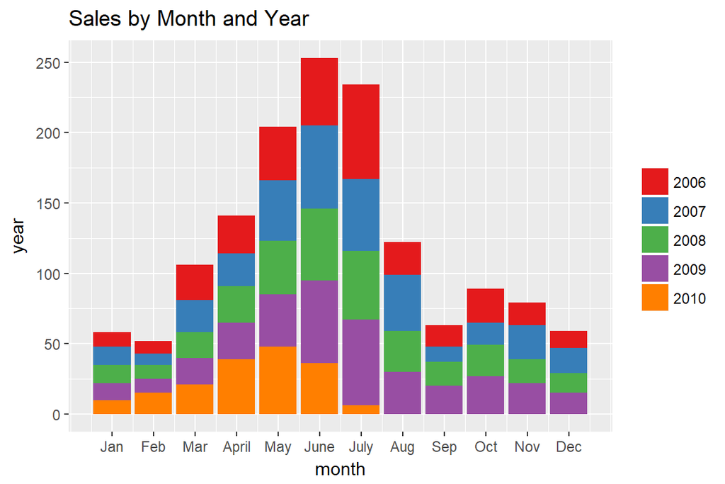

#### Observations:

- The plot show that in the last year of the sample (2010), there are no data for the months of August, September, October, November and December.
- The data of the month of July seems to be incomplete, since this is the month with a high number of sales.

### Sales Revenue by Month without 2010

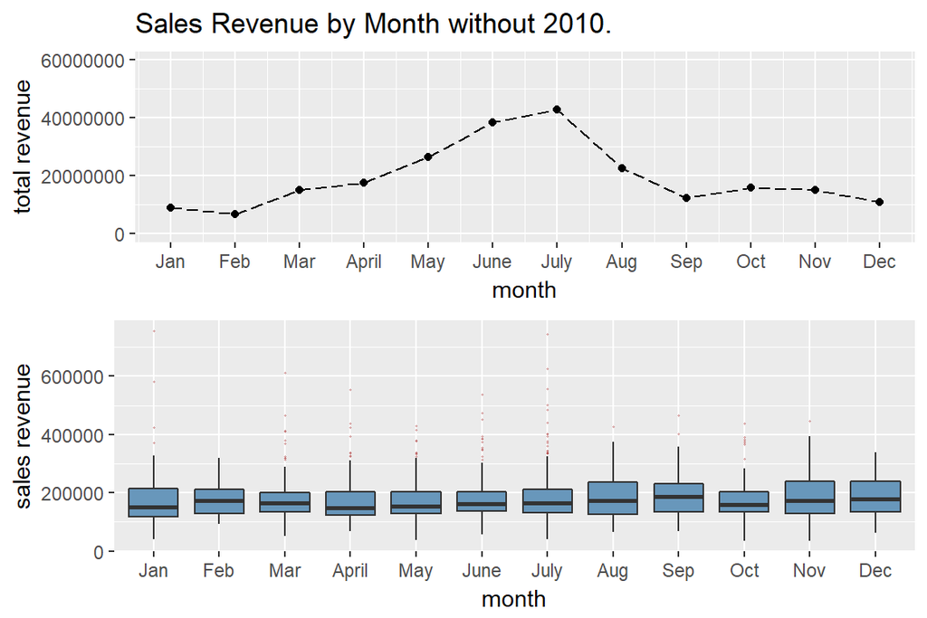

### Prices by Neighborhood

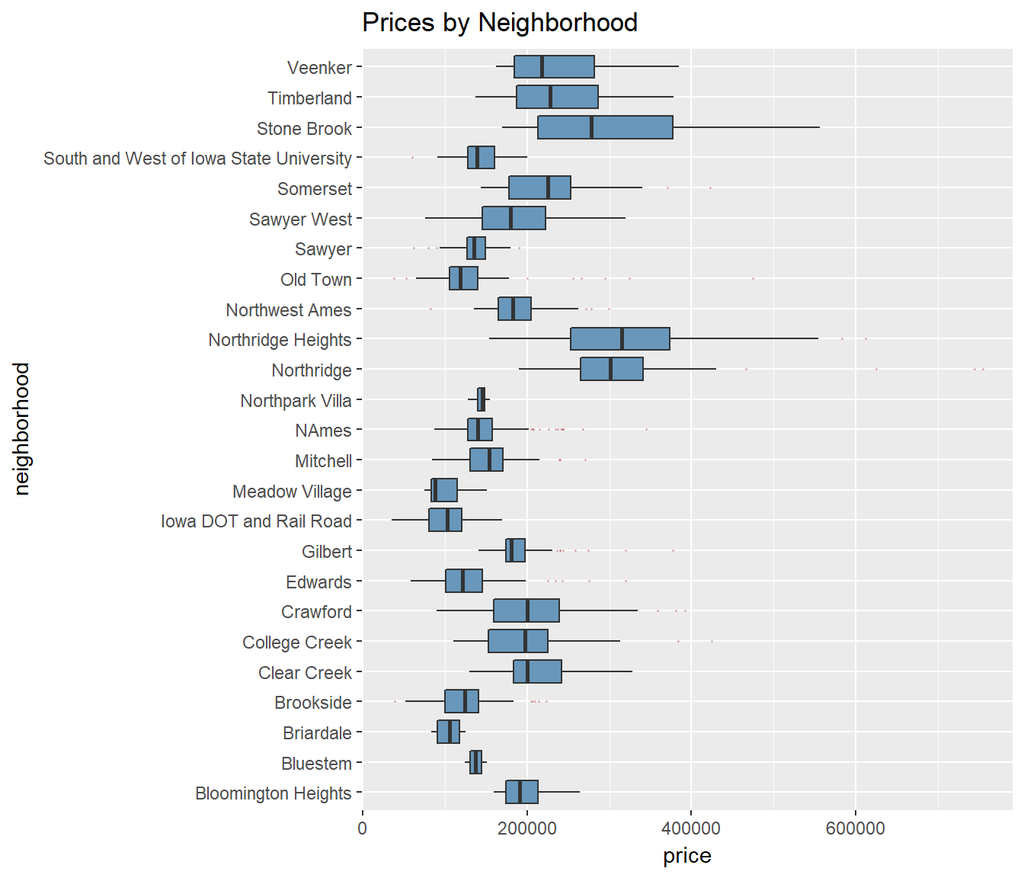

### Number of Sales by Neighborhood and Zoning Type

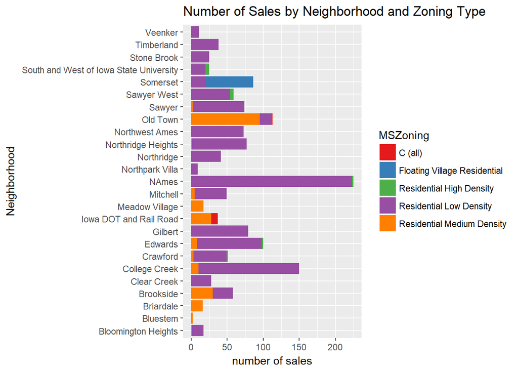

#### Observations:

Most of the neighborhoods have the zoning type ‘Residential Low Density’ as their predominant type. Some of the exceptions are Old Town, Briardale, Iowa DOt and Rail Road, Meadow Village and Somerset. This is interesting because, excluding Somerset (which also have a different zoning type) all of them have a relatively low median sale price.

Another interesting thing is that the commercial properties are concentrated in Iowa Dot and Rail Road; and the Floating Village Residential’s properties are concentrated in Somerset.

One thing that may be interesting to check is the relationship between the zoning types and the size of the properties.

### Lot Size versus Zoning Type

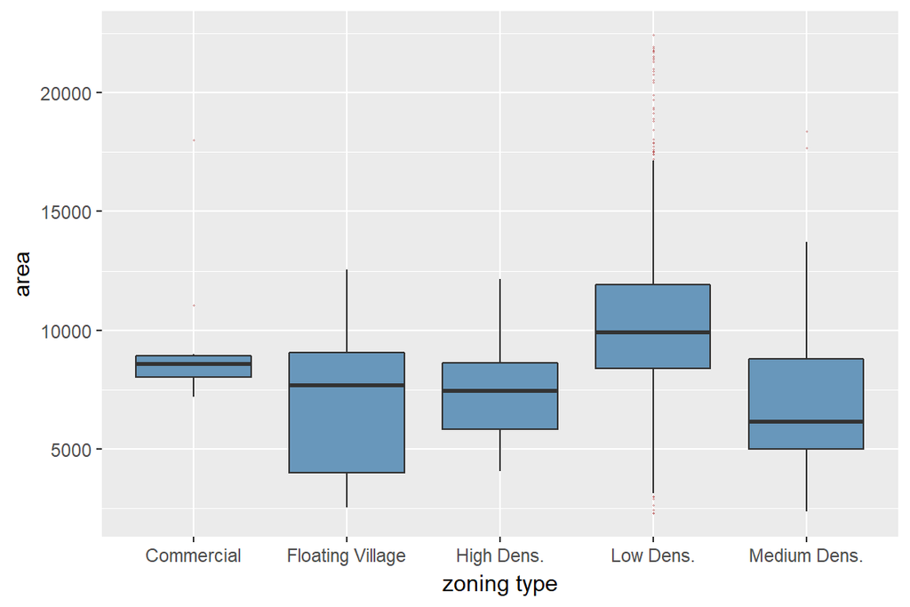

#### Observations

The properties of the Residential Low Density have a lot of outliers and, at the same time, also have the highest range of area.

## Features - Distribution

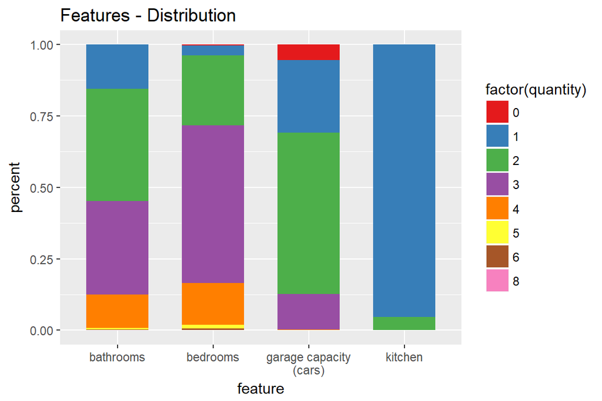

#### Observation

Let’s see if there is a linear relationship between those variables and the price of the house. I’ll ignore the Kitchen variable, since the majority of the houses only have one kitchen.

### Features versus Price

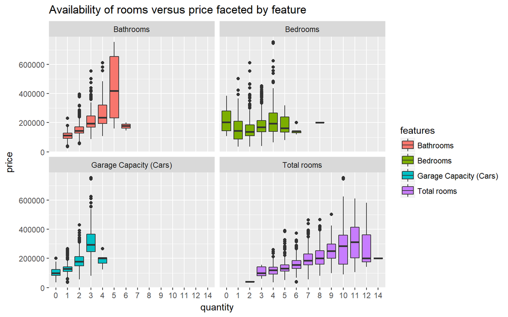

```
## The correlations for the bathrooms, bedrooms,
## garage capacity and total rooms are, respectively:
##
## 0.61
## 0.17
## 0.64
## 0.53
```

#### Observations:

It seems that there is a linear relationship between price and the availabity of space in the garage, the number of bathrooms and the total number of rooms. On the other hand, it seems that there isn’t a linear relationship between the number of bedrooms and the price of the house.

This shows that the constructed area of the house may be a very important feature to understand the price of the house. Unfortunately, this dataset doesn’t have this variable.

I will try to estimate this by adding the total area of the basements with the area of the first and second floor.

## House Size - Distribution

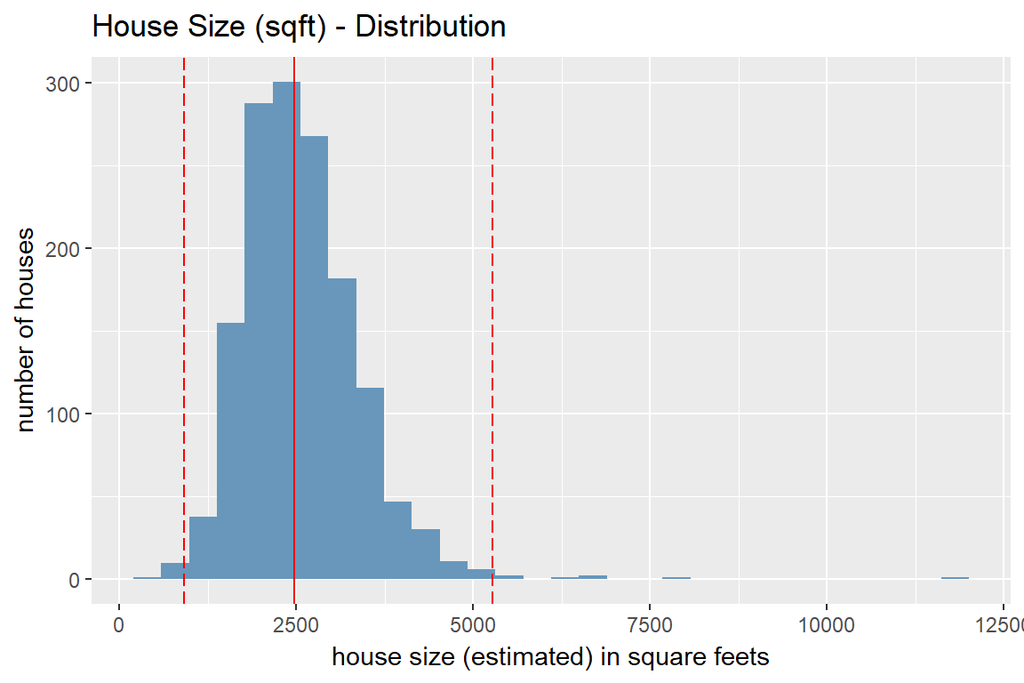

```
##    Min. 1st Qu.  Median    Mean 3rd Qu.    Max.
##     334    2010    2474    2567    3004   11752
```

#### Observations:

This chart show that the distribution is a little bit skewed to the right, especially, because of the upper outliers that are very higher than the third quantile. In the following plots, when I have to use this variable, I will limit the upper and lower limits in order to improve the interpretability of the plot, using only the data between the 0.5 and 99.5 percentiles.

But, just to show the difference of using the outliers I’ll do a comparative plot.

### Constructed Area versus Price

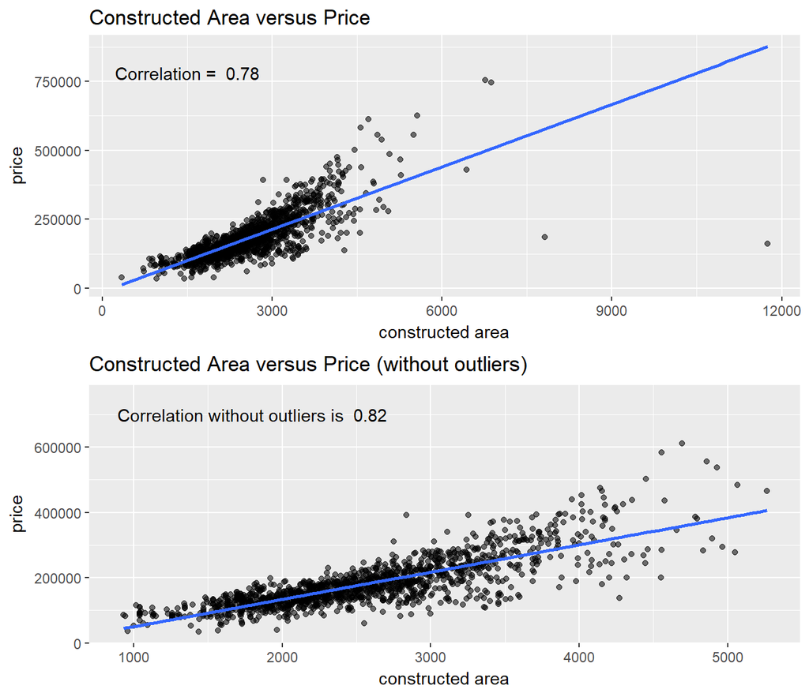

#### Observations:

- It seems that the value estimated is very correlated with the price of the houses. It gets even more correlated when the outliers in the variable that was created are removed from the dataset.
- As I saida, from now on, every time that I use the variable `house_size`, the outliers will be removed using the xlim to improve the interpretability.

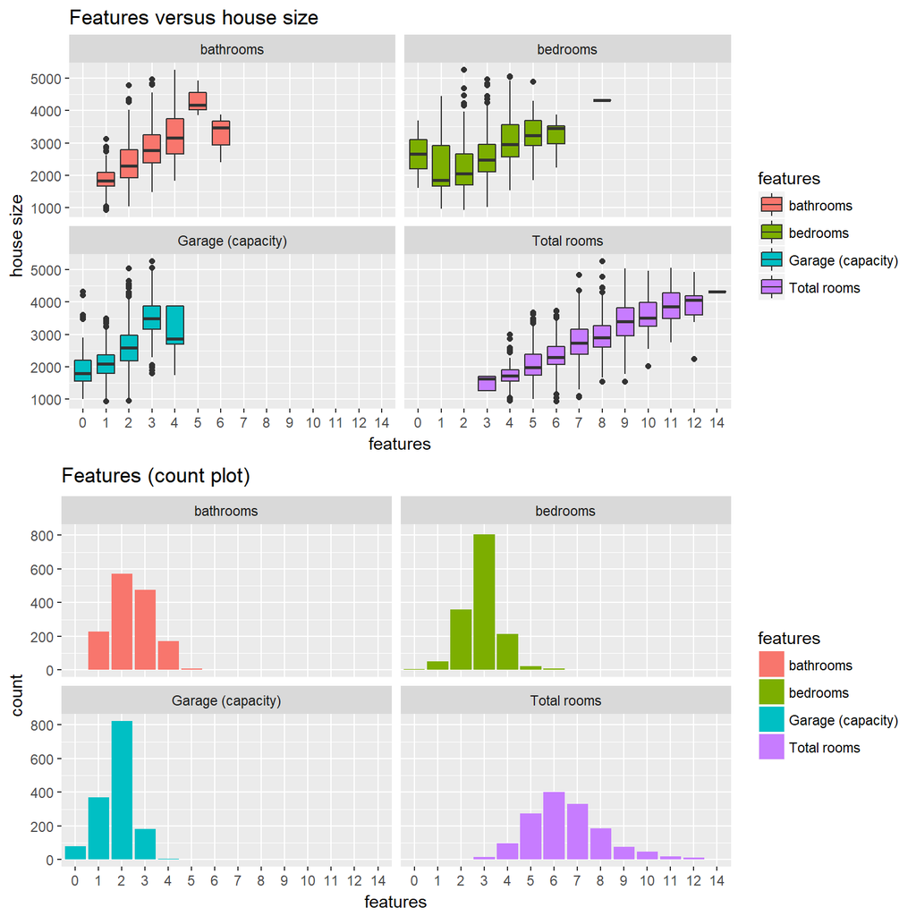

```
## The correlations for the bathrooms, bedrooms,
## garage capacity and total rooms are, respectively:
##
## 0.58
## 0.35
## 0.54
## 0.67
```

#### Observations:

There is a positive linear relationship between the variable that I have created to represent the size of the house and the other variables. However, the correlation between them is not so high.

Sometimes, boxplots can be misleading because they doesn’t show how many observations are in each of the boxes. In this case for example, there are some strange things like a house with no bedrooms having a median price higher than one house that has a bedroom. Or a house with 6 bathrooms being smaller than a house with 5 bathrooms. In both of the cases, the data available is not enough to infer that houses with less bathrooms or bedrooms are bigger than houses with more bathrooms.

## Age of the house versus Sale Price

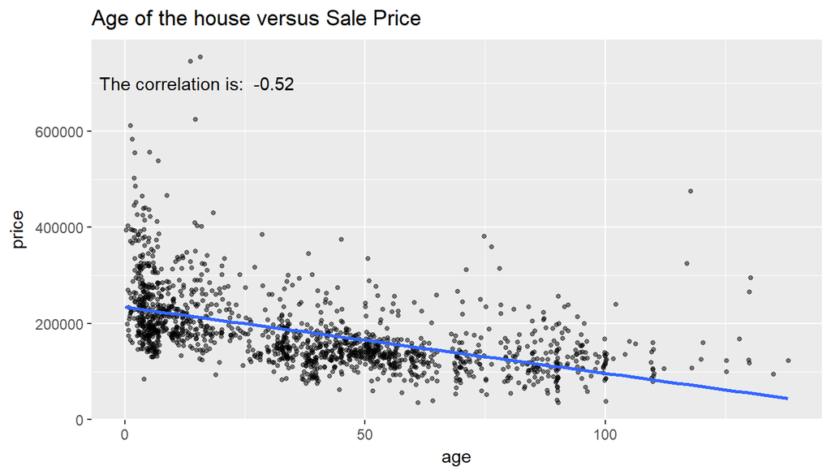

#### Observations:

The correlation between the two variables is medium, but it doesn’t seem to have a normal linear relationship between the variables, especially, when you look at new houses where the range of prices is very high.

## Sale Price versus Overall Quality

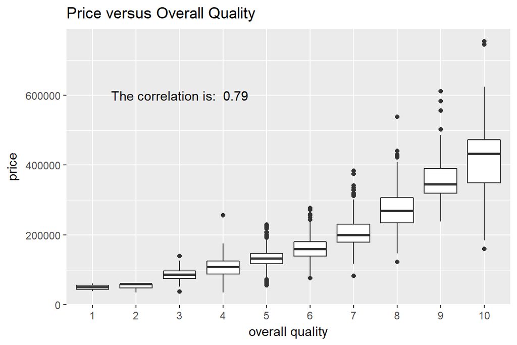

#### Observations:

There is a positive linear relationship between the variables and the correlation is high.

# Bivariate Analysis

In this section, a lot of relationshipts were found between the price of the house and the other variables. The most significant relationships happened between the response variable and the variables `ÒverallQual` and `house_size`.

It’s important to remember that the variable `house_size` was created by merging the area in square feet of the first floor, second floor and basement. I have done that because I have realized that most of the variables related to area have a relationship with the price.

Some interesting relationships were also observed between the explanatory variables like between `MSZoning` and `Neighborhood` or between the volume of sales and the month.

In the next section, I’m planning to use the relationship between the `house_size` and `SalePrice` to understand how some categorical variables are related to them. Some examples are:

- Neighborhood: neighborhood of the house.
- Overall Quality: quality of the house.
- MSZoning: zoning type.
- TotRmsAbvGd: total rooms above grade
- GarageCars: capacity of the garage in cars.
- age: age of the house.

# Multivariate Plots Section

## Price versus Estimated House Size and Overall Quality

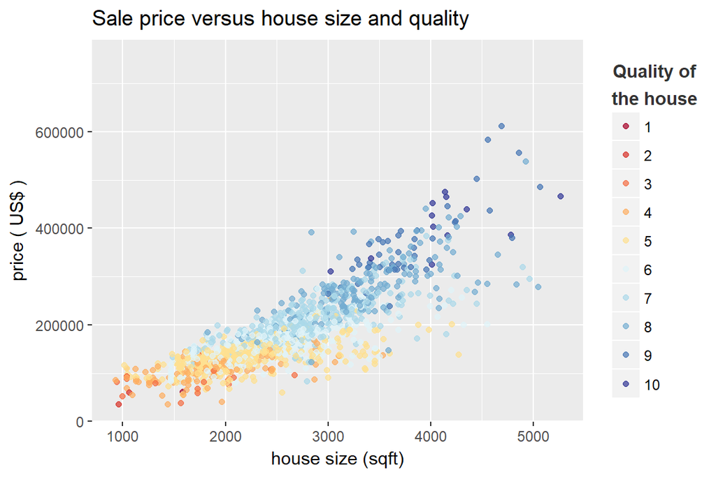

#### Observations:

Here we can see that there is a positive linear relationship between the variables because the value of the overall quality is growing together with size of the house and the price of the house.

The majority of the houses that have been sold by more than 300.000,00 had an evaluation of quality higher than 8 and were bigger than 3000 square feets. On the other had, small houses with a bad evaluation, are more likely to have been sold for less than 150.000,00.

## Sale price versus house size and zoning type

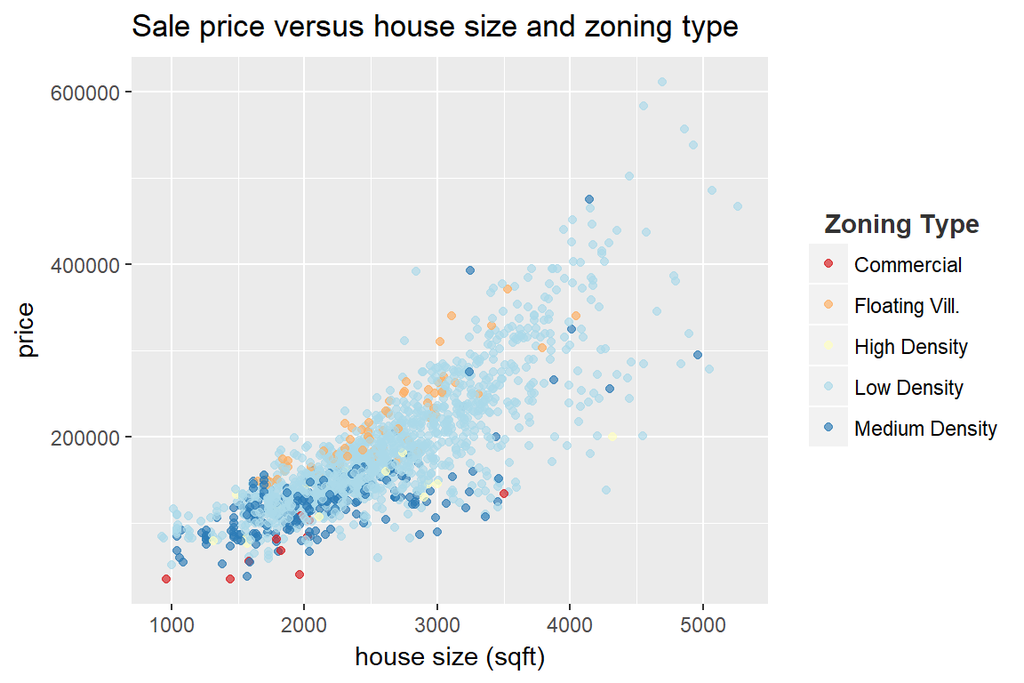

#### Observations:

As expected, based on the other plots related to the zoning type, properties of the Residential Low Density and of the Floating Village Residential are, in general, bigger and expensive than the properties located in the other types of zoning.

## Sale price versus house size and garage capacity

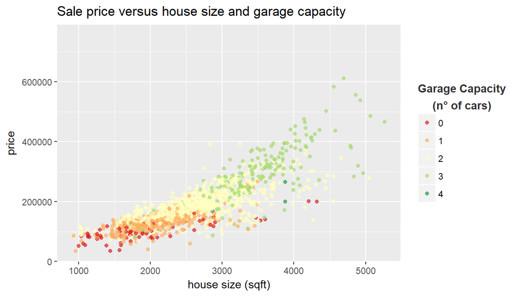

#### Observations

Here we can see that in, general, bigger houses have more space on the garage. What about the type of the garage, is there any pattern on this matter too?

## Sale price versus house size and garage type

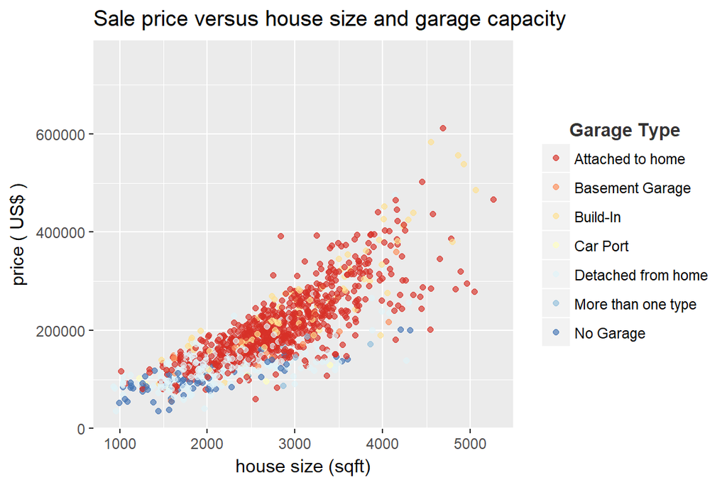

#### Observations:

- The most common type of garage is `attached to home`, being present, especially, in houses that are bigger than 2000 square feets. On the other hand, houses that have less than 2000 square feets are more diverse in the types of garage and the most common types are: ``No Garage` and `Detached from home`.

## Sale Price versus size of the house and age

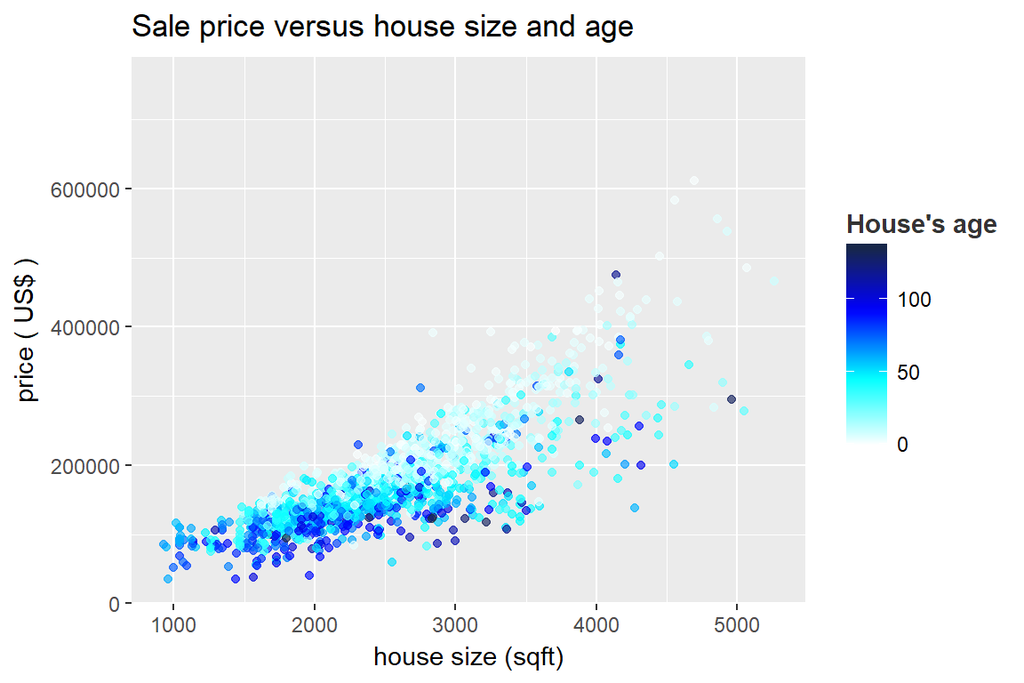

#### Observations:

This plot had shown that the age of the house is correlated with the size and, especially, the price of the house.

However, the age is complicated to be a measure of quality of the house because many of them go through rebuildings during their existence.

## Sale price versus house size and total rooms

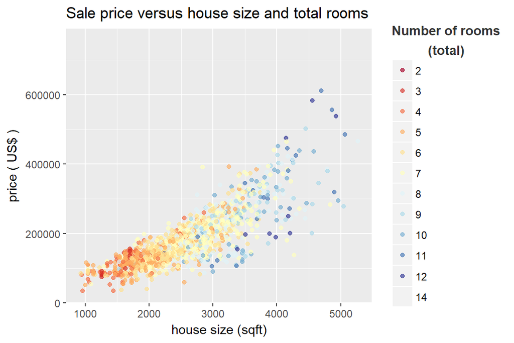

#### Observations:

As we had already see in the earlier sections, the total number of rooms is very correlated with the price and the house size.

## Sale price versus house size and bathrooms

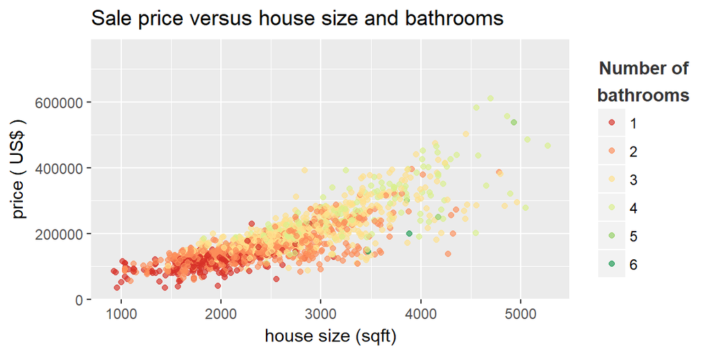

## Price versus house size and house quality faceted by neighborhood

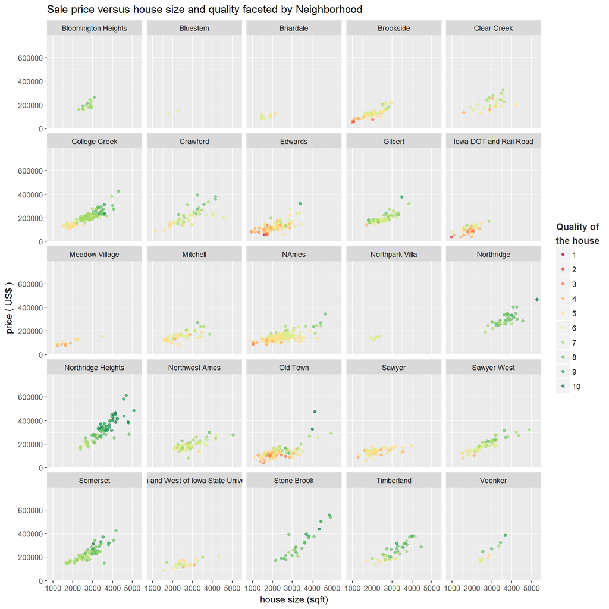

#### Observations:

Somethings called my attention. Firstly, is the fact that the slope and the incercept for the variables house size and price change a lot depending in the neighborhood. There are places like Sawyer that, even though there is a positive variation on the size of the house, the variation on the price is small. On the other hand, in neighborhoods like Stone Brook have almost a perfect correlation between size and price.

Another thing that called my attention is the fact that the majority of the high quality properties (8+) are concentrated in few neighborhoods: Northridge Heights, Northridge, Somerset and Stone Brook. Those neighborhoods, as we saw earlier, have the highest median prices within our sample.

On the other hand, neighborhoods like North Ames, Old Town, Edwards, Brookside and Iowa DOT and Road, concentrates the majority of the “Low” quality propertiers. One thing that could be useful, but we doesn’t have the data, was to check if there is a relationship between the quality of the property and the income of the family.

Lastly, some places almost doesn’t have sales of houses, Bluestem, for example, only have two houses sold in almost five years. The question is nobody wants to buy houses in this neighborhood? Or there isn’t people trying to sell their houses there? Or Both of them? With the data available, unfortunately, we are not able to answer this question.

# Multivariate Analysis

In general, this section was like a confirmation section of the findings of the past sections. We could see that there is a correlation between the features and if I would a make a model, I would have to use VIF to avoid collinearity in our model, since most of the variables explored are correlated with both the response variable and the size of the house.

The most interesting finding was the difference in the slopes and intercepts depending on the quality of the house and the neiborghood that those house are located,

The main exploratory variables in our model are Overall Quality, House Size and Neighborhood.

# Final Plots and Summary

### Plot One

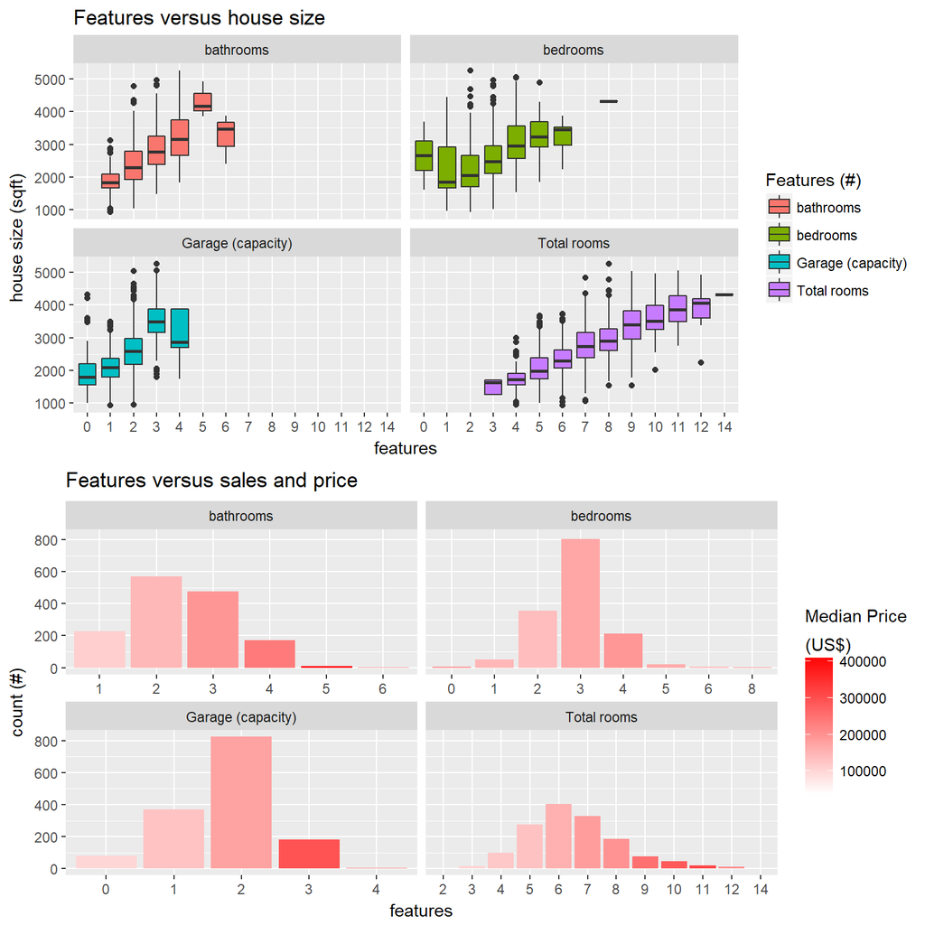

### Description One

I have chose this plot because it shows some interesting things. Firstly, in the first part of the plot we can see that the amount of feature is positively correlated with the area of the house. There is also some misleading cases because of the nature of boxplots like houses with no bedrooms being bigger than houses that have a bedroom or houses with a space for 4 cars being smaller than houses with a space for three cars.

In order to avoid misunderstandings, I have created the barplot to show how much houses have each amount of each feature to validate if in those situations the data available is enough to be relevant. It turns out that in both of the cases, the data available is very small.

Besides that, the last objective of this plot is to show that the higher the amount of each feature, the higher the median price of the house, except in the case of the bedrooms, where the correlation is very small.

### Plot Two

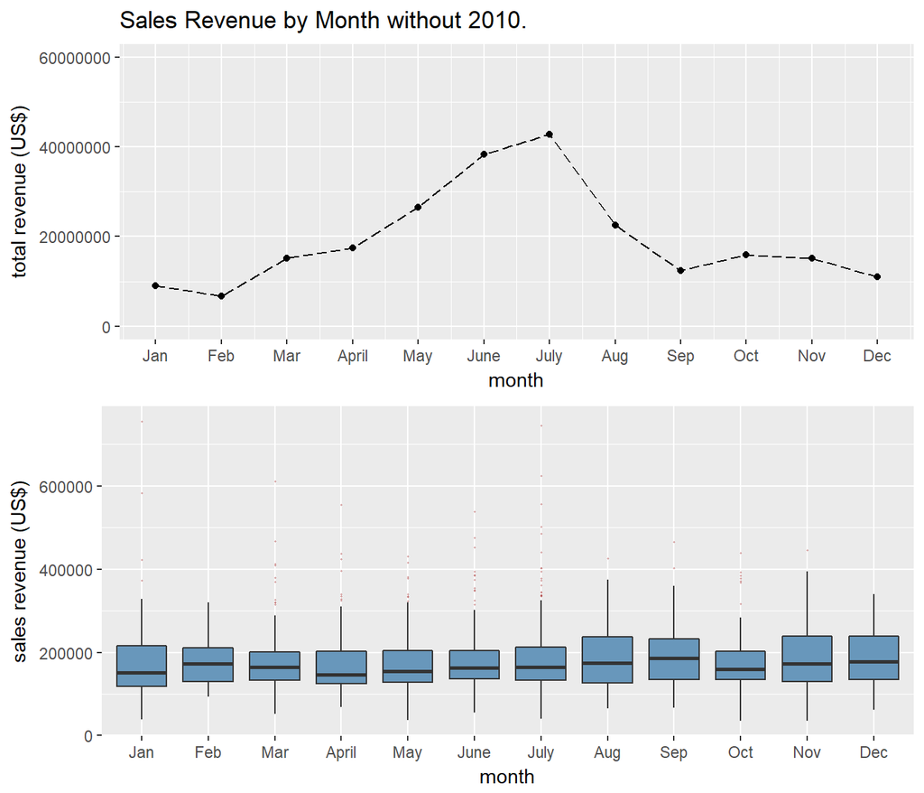

### Description Two

So, I have subsetted the dataframe, to identify another information:

Does the total revenue also is also bigger from April to August in the dataset? If this trend is correct, is this happening because of a increase in the volume of sales or because of a increase in the median price?

So, I have created those two plots, the first one is showing the total sales by month which follows the same trend of volume of sales. The second plot show the summary statistics like median, range, etc.

The median doesnt’t vary much along the months, so the volume of sales is more important, in this case, to understand why the sales increase in the middle of the year.

### Plot Three

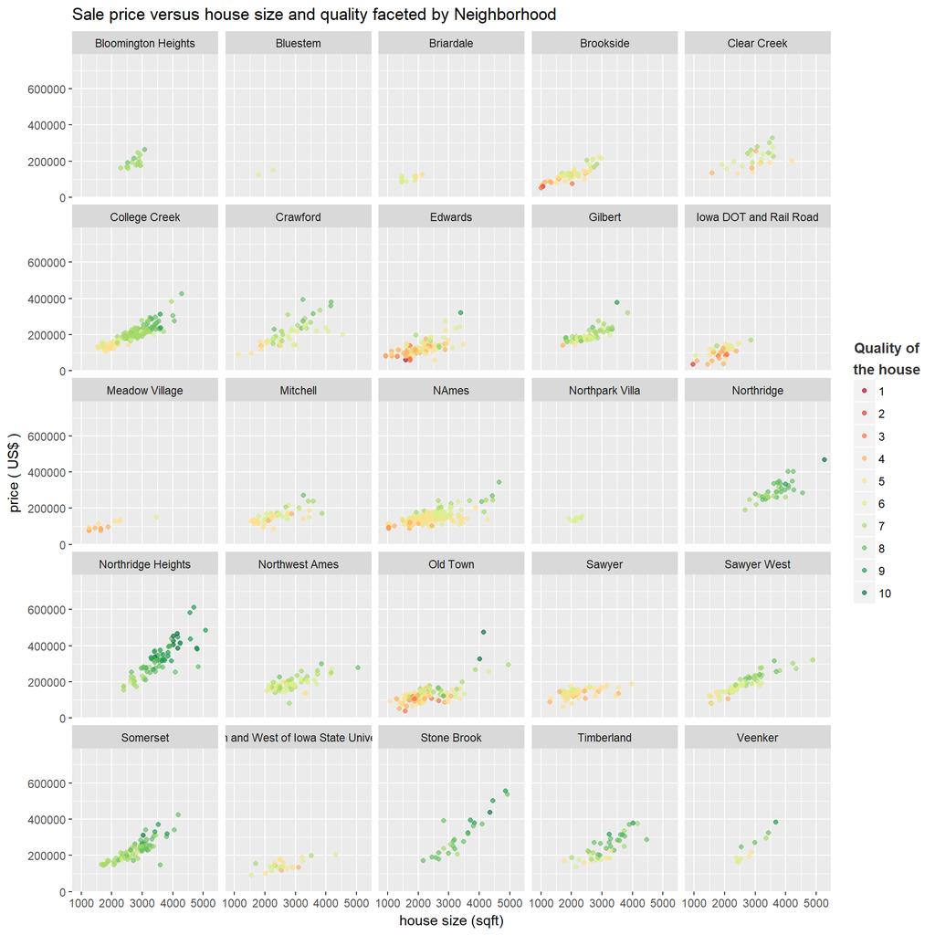

### Description Three

In my opinion, this was the most important plot in the analysis because it shows the data in a disagregatted way and we can detect different patters that we would be unable to see in a single scatter plot.

The combination of color and faceting showed that the slope and the intercept of the scatterplot depends on the neighborhood and in the quality of the house. In some cases, is almost a perfect linear relationship (Stone Brook), in others like in the neighborhood of Sawyer the correlation is very weak.

Besides that, we could also see which of the neighborhoods had a higher and a lower number of sales between 2006 and 2010.

# Reflection

## Insights:

Based on the exploratory analysis, that I’ve done the variables with the higher correlation with the price are:

- Quality of the house
- Garage Capacity (cars)
- House Size
- Age of the house
- Total rooms
- Neighborhood
- Number of bathrooms

If I had to create a model to predict the price, I would have to use VIF to check for collinearity and some variables may not be useful for the model. But, the result with only some of this variables would be good.

There are other variables that are good too, but I have not pick them for this project because it would become bigger, this dataset has a lot of variables.

Creating the storetelling was the most difficult part, especially, the selection of plots to keep in the project and the creation of the narrative.

Besides that, the project could be better if I have data from the income of the families and geospatial data of Ames because this would increase the kinds of plots and relationships to explore.

# Resources used:

- [GGplot2 Cheatsheet](https://www.rstudio.com/wp-content/uploads/2015/03/ggplot2-cheatsheet.pdf)
- Data.table - Documentation (inside R)
- [Sequential, diverging and qualitative colour scales](https://ggplot2.tidyverse.org/reference/scale_brewer.html)
- [Chunk Options](https://yihui.name/knitr/options/)
- [Annotation Layer](https://ggplot2.tidyverse.org/reference/annotate.html)
- [R Graph Gallery](https://www.r-graph-gallery.com/)
- [Legend](http://www.sthda.com/english/wiki/ggplot2-title-main-axis-and-legend-titles)